# A23.20 変位法による解析

（仮定された）平均ねじれ率 $\theta$ は、ボックスの中間点にある代表的な断面における $GJ$ を使用して近似的に計算される。*

$$\theta = \frac{T}{GJ} = \frac{P_m b_m - P_n b_n}{GJ}$$

次に、変位 $\delta_n$ および $\delta_m$ は以下のように与えられる。

$$\delta_n = \theta L_n b_n = \frac{P_m b_m - P_n b_n}{GJ} L_n b_n$$

$$\delta_m = \theta L_m b_m = \frac{P_m b_m - P_n b_n}{GJ} L_m b_m$$

有効固定根元に関するモーメントの総和をとることで、 $P_n$ は $P_m$ の項で表され、上記の方程式から消去されて以下のようになる。

$$\delta_n = \frac{P_m L_n b_n}{GJ} \frac{L_n b_m + L_m b_n}{L_n}$$

$$\delta_m = \frac{P_m L_m b_m}{GJ} \frac{L_n b_m + L_m b_n}{L_n}$$

一角（例えば点 m）の変位のみが角反力に関連付けられるため、 $\delta_n$ をゼロにするために、ボックスは有効固定根元軸の周りに回転される。その結果生じる点 m の全変位は以下のようになる。

$$\delta_{m\text{TOTAL}} = \delta_m + \frac{L_m}{L_n} \delta_n$$

$$= \frac{P_m L_m}{GJ} \left( \frac{L_n b_m + L_m b_n}{L_n} \right) (b_n +
b_m)$$

これを再度解くことで、次のように書ける。

$$P_m = \frac{GJ}{L_m (b_n + b_m)} \frac{L_n}{(L_n b_m + L_m b_n)}$$

この最後の式は、他の3つの角が変位していない状態での、点 m における荷重とその点における変位を関連付けている。したがって、定義された点 m の変位は面 mnrs に対する相対的なものであった。この相対変位は、幾何学的に4つの角すべてが変位している場合（実際には剛体変位を除去した状態）に関連付けることができる。

$$\delta_{m\text{relative}} = \left[ \begin{array}{cccc} 1 & -L_m/L_n
& A_1 & A_2 \end{array} \right] \left\{ \begin{array}{c}
\delta_m \\ \delta_n \\ \delta_r \\ \delta_s \end{array} \right\}$$

ここで、

$$A_1 \equiv \frac{L_n b_m + L_m b_n + b_s(L_m - L_n)}{L_n (b_r + b_s)}$$

$$A_2 \equiv \frac{-(L_n b_m + L_m b_n) + b_r(L_m - L_n)}{L_n (b_r + b_s)}$$

この最後の関係は、本章の式17に対応する。その後、式26を使用することで、次の正方剛性マトリクスが得られる。

$$\begin{array}{c} m \\ n \\ r \\ s \end{array} \left[ K \right] =
\frac{GJ \ L_n/L_m}{(L_n b_m + L_m b_n)(b_n + b_m)} \left\{
\begin{array}{c} 1 \\ -L_m/L_n \\ A_1 \\ A_2 \end{array} \right\} \left[
\begin{array}{cccc} 1 & -L_m/L_n & A_1 & A_2 \end{array}
\right]$$

上記の導出では、代表断面におけるねじり剛性 $GJ$ が使用されている。剛性は、単一セルの薄肉閉断面管のねじりに対するブレートの式（第A6章、式18）から得られる。

$$\theta = \frac{T}{4A^2 G} \oint \frac{ds}{t}$$

これより、定義により次のようになる。

$$GJ = \frac{4A^2 G}{\oint \frac{ds}{t}}$$

ここで、 $A$ は管壁の中間線によって囲まれた管断面積であり、積分は管の外周に沿って行われる（添字 s は外周に沿った距離を示す）。デルタ翼に見られるトルクボックスについては、垂直ウェブからの $ds/t$ の寄与はカバーシートからの対応する寄与と比較して小さいため、これを無視してもおそらく問題ない。

例題の翼では、3つのボックス（2-3-5-6、3-4-6-7、6-7-8-9）が使用される。これらのボックスは、平面図でそれぞれ48インチの正方形であり、代表断面の平均深さ（ここでは均一な深さと仮定）はそれぞれ 7.26”、5.32”、4.27” である。図 A23.31 は、ボックス 2-3-5-6 の仮定された代表断面とその $GJ$ 計算を示している。

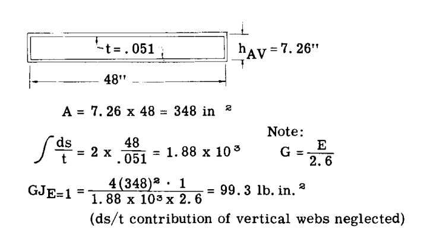

図 A23.31

同様の方法で、以下が得られる。

ボックス 3-4-6-7 について：

$$GJ_{E=1} = 53.3$$

ボックス 6-7-8-9 について：

$$GJ_{E=1} = 34.3$$

最終的に、例題の3つのボックスの剛性マトリクスは以下のようになる。

ボックス 2-3-5-6 について：

$$[K] = 0.000898 \left[ \begin{array}{rrrr} 1 & -1 & -1 & 1 \\
-1 & 1 & 1 & -1 \\ -1 & 1 & 1 & -1 \\ 1 & -1
& -1 & 1 \end{array} \right]$$

ボックス 3-4-6-7 について：

$$[K] = 0.000482 \left[ \begin{array}{rrrr} 1 & -1 & -1 & 1 \\
-1 & 1 & 1 & -1 \\ -1 & 1 & 1 & -1 \\ 1 & -1
& -1 & 1 \end{array} \right]$$

ボックス 6-7-8-9 について：

$$[K] = 0.000310 \left[ \begin{array}{rrrr} 1 & -1 & -1 & 1 \\
-1 & 1 & 1 & -1 \\ -1 & 1 & 1 & -1 \\ 1 & -1
& -1 & 1 \end{array} \right]$$

## 全体変位／座標変換

前述の要素剛性マトリクスの要素変位は、翼全体の構造に対して選択された全体変位に関連付け（変換）することができる。図 A23.32 は、選択可能な全体変位を示している。

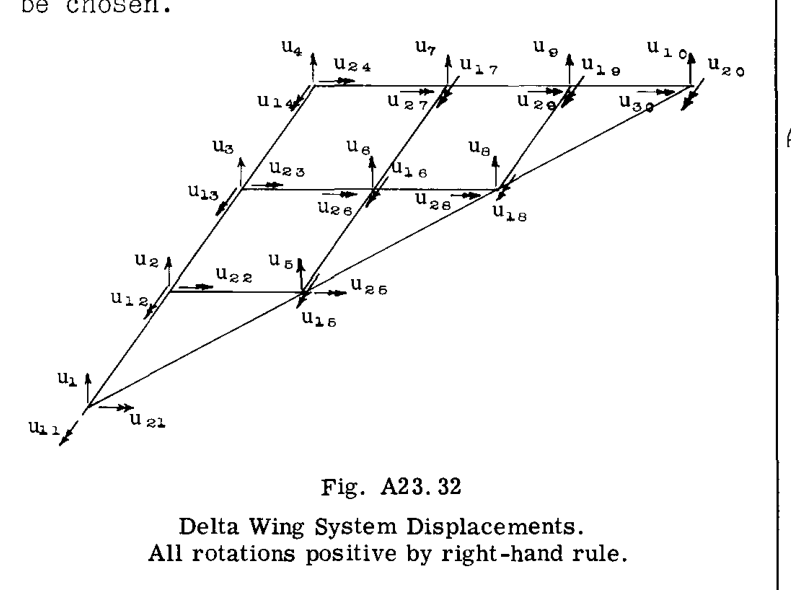

図 A23.32

ここで、変位を変換する関係式を記述する。例として、以下のように書くことができる。

$$\beta_{2-5} = \begin{array}{c} u \\ \delta \\ \hline 1 \\ 2 \\ 3 \\ 4
\end{array} \left[ \begin{array}{ccccccccccccccccccccc} 1 & 2 &
3 & 4 & 5 & 6 & \cdots & 11 & 12 & 13 &
14 & 15 & 16 & \cdots & 29 & 30 \\ \hline 0 & 1
& 0 & 0 & 0 & 0 & \cdots & 0 & 0 & 0
& 0 & 0 & 0 & \cdots & 0 & 0 \\ 0 & 0 &
0 & 0 & 0 & 0 & \cdots & 0 & 1 & 0 & 0
& 0 & 0 & \cdots & 0 & 0 \\ 0 & 0 & 0 &
0 & 1 & 0 & \cdots & 0 & 0 & 0 & 0 & 0
& 0 & \cdots & 0 & 0 \\ 0 & 0 & 0 & 0 &
0 & 0 & \cdots & 0 & 0 & 0 & 0 & 1 & 0
& \cdots & 0 & 0 \end{array} \right]$$

したがって、

$$\left[ K_{2-5} \right] = \beta'_{2-5} \ k_{2-5} \ \beta_{2-5}$$

$$= \begin{array}{c} \\ 2 \\ 5 \\ 12 \\ 15 \end{array} \left[
\begin{array}{cccc} 2 & 5 & 12 & 15 \\ \hline .003850 &
-.003850 & .1108 & .07404 \\ -.003850 & .003850 & -.1108
& -.07404 \\ .1108 & -.1108 & 3.929 & 1.387 \\ .07404
& -.07404 & 1.387 & 2.167 \end{array} \right]$$

簡潔にするために、ここでは変換された要素剛性マトリクスの非ゼロ項のみを記述している。座標回転を伴わないこれらの単純な変換は、要素 2-5 について明らかに次のようになるため、目視で記述することができる。

$$\delta_1 \rightarrow u_2$$

$$\delta_2 \rightarrow u_{12}$$

$$\delta_3 \rightarrow u_5$$

$$\delta_4 \rightarrow u_{15}$$

前縁スパーについては、幾何学的な変換が存在する。したがって、要素 1-5 については次のようになる。

$$\beta_{1-5} = \begin{array}{c} u \\ \delta \\ \hline 1 \\ 2 \\ 3 \\ 4
\end{array} \left[ \begin{array}{cccccc} 1 & 5 & 11 & 15
& 21 & 25 \\ \hline 1 & 0 & 0 & 0 & 0 & 0 \\
0 & 0 & .707 & 0 & .707 & 0 \\ 0 & 1 & 0
& 0 & 0 & 0 \\ 0 & 0 & 0 & .707 & 0 &
.707 \end{array} \right]$$

ここでも、非ゼロのエントリを持つ変位のみを明示的に示している。

したがって、

$$K_{1-5} = \beta'_{1-5} \ k_{1-5} \ \beta_{1-5}$$

$$= \begin{array}{c} \\ 1 \\ 5 \\ 11 \\ 15 \\ 21 \\ 25 \end{array} \left[
\begin{array}{cccccc} 1 & 5 & 11 & 15 & 21 & 25 \\
\hline .0005295 & -.0005295 & .01326 & .01214 & .01326
& .01214 \\ -.0005295 & .0005295 & -.01326 & -.01214
& -.01326 & -.01214 \\ .01326 & -.01326 & .4361 &
.2004 & .4361 & .2004 \\ .01214 & -.01214 & .2004 &
.3821 & .2004 & .3821 \\ .01326 & -.01326 & .4361 &
.2004 & .4361 & .2004 \\ .01214 & -.01214 & .2004 &
.3821 & .2004 & .3821 \end{array} \right]$$

上記と同様の方法で、15個のすべての梁要素の剛性マトリクスが変換される。トルクボックスは、それぞれの4つの角のグリッド番号によって指定されているため、すでに「全体」座標系にある。

## 部分構造による解析

この時点から、解析は以前に説明したように非常に直接的な方法で進行する。しかし、多くの節点を持つ大規模な構造をこのような完全に要素的な方法で解析すると、非常に高次のマトリクス方程式が生じることは明らかである。

しかし、要素を部分構造に事前結合することによって、問題の次数を下げることが可能である。その過程で、以下のいずれかを行うことができる。

1. 先験的な情報（a priori information）を用いて一部の荷重（および対応する変位）を消去する。
2. 問題の一部を主要な計算から切り離し、部分構造上で解決される副問題に置く。

これらの手法は、次のセクションで採用される。

図 A23.32 の変位に関連する外力の一部は、この問題で使用される荷重モデルの性質上、ゼロであることが知られている。したがって、横方向の力 $F_5$ から $F_{10}$ のみが翼のグリッド点に荷重として適用され、これらは横方向の荷重 $F_1$ から $F_4$ 、および航空機の中心線に沿ったロールモーメント $F_{11}$ から $F_{14}$ によって反力を受ける。

この構造とこの荷重において、多くの要素荷重がゼロであることが先験的に知られている。例えば、グリッド点 10 における梁要素にはモーメントは作用しない。* これは実質的に、このジョイントがピンジョイントであり、その平行移動のみが考慮される場合と同様である。

多くの要素荷重はゼロではないが、それらが包含されている部分構造の解析によって後で計算できる場合、主要な問題において明示的に解く必要はない。例えば、グリッド点 9 で交わる梁要素 7-9 と 9-10 の曲げモーメントは等しく、点 10 における横方向の要素荷重がわかれば容易に求めることができる。

この問題に対して選択された部分構造と、それらの要素変位を図 A23.33 に示す。これらは、必要最小限の変位のみを考慮した、連続する翼梁（スパーおよびリブ）の極めて自然な選択である。前述の推論は主に力に関するものであったが、変数として使用され、図に示されているのは対応する要素変位である。

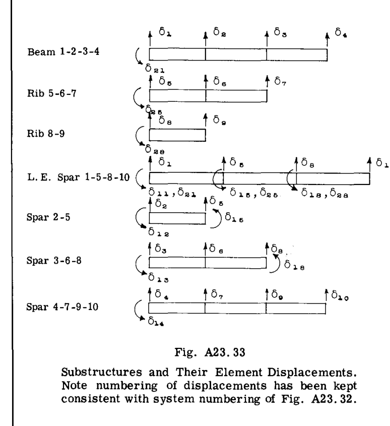

図 A23.33

スパー 4-7-9-10 の部分構造は、部分構造変数の選択における動機を示している。グリッド点 7、9、10 に作用する外力モーメントがないことがわかっていたため、それらの点における回転変位を考慮する必要がないように、図示のようにモデル化された。無荷重点における変位の消去は、当然ながら、最終的な全体システム剛性マトリクス上で行うことができる（式35により縮小剛性マトリクスを得る）。このような縮小には、非常に大きなマトリクスの操作が伴う場合がある。部分構造を使用すると、この縮小プロセスは、主要問題の次数を同時に下げながら、いくつかの小さく扱いやすい問題に分割される。このようにして消去された回転変位は、必要に応じて副計算（式33を参照）を介して容易に取得できる。

3つ以上の非直交する梁要素が交差してそれらの相互作用を考慮する場合、モーメントが作用すると考える必要がある。したがって、すべてのリブとスパーが交差するグリッド点 5 と 8、およびグリッド点 1 における回転変位を考慮する必要がある。（もう一方の翼半分がその点における3番目の構造を提供する。）

## 部分構造剛性マトリクス

部分構造剛性マトリクスの計算は、要素で構成される任意の構造に対して確立された手順に従う。例えば、要素 3-6 および 6-8 を含む梁 3-6-8 を考える。部分構造は、適用される荷重 $P_{16}$ がゼロであることが知られているために消去される予定の $\delta_{16}$ を含む、すべての変位が示された状態で以下に示されている。

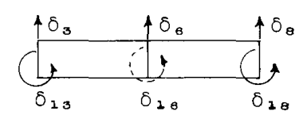

梁 3-6-8 部分構造

剛性マトリクスは、要素 3-6 および 6-8 のそれぞれの剛性マトリクスから集められる。

$$K_{3-6} = \begin{array}{c} \\ 3 \\ 6 \\ 13 \\ 16 \end{array} \left[
\begin{array}{cccc} 3 & 6 & 13 & 16 \\ \hline .004746 &
-.004746 & .1166 & .1112 \\ -.004746 & .004746 & -.1166
& -.1112 \\ .1166 & -.1166 & 3.775 & 1.819 \\ .1112
& -.1112 & 1.819 & 3.521 \end{array} \right]$$

$$K_{6-8} = \begin{array}{c} \\ 6 \\ 8 \\ 16 \\ 18 \end{array} \left[
\begin{array}{cccc} 6 & 8 & 16 & 18 \\ \hline .002558 &
-.002558 & .07305 & .04974 \\ -.002558 & .002558 &
-.07305 & -.04974 \\ .07305 & -.07305 & 2.574 & .9325 \\
.04974 & -.04974 & .9325 & 1.455 \end{array} \right]$$

これらを足し合わせると、次のようになる。

$$K_{3-6-8} = \begin{array}{c} \\ 3 \\ 6 \\ 8 \\ 13 \\ 16 \\ 18
\end{array} \left[ \begin{array}{cccccc} 3 & 6 & 8 & 13
& 16 & 18 \\ \hline .004746 & -.004746 & & .1166
& .1112 & \\ -.004746 & .007304 & -.002558 & -.1166
& -.0382 & .04974 \\ & -.002558 & .002558 & &
-.07305 & -.04974 \\ .1166 & -.1166 & & 3.775 &
1.819 & \\ .1112 & -.0382 & -.07305 & 1.819 & 6.095
& .9325 \\ & .04974 & -.04974 & & .9325 & 1.455
\end{array} \right]$$

（空欄はゼロを示す）

一般化力 $u$ がゼロであるという拘束条件が、式35を使用して適用される。この場合の逆行列 ” $K_{ss}^{-1}$ ” は単に $1/6.095$ であり、マトリクス ” $K_{rs}$ ” は行 $(.1112, -.0382, -.07305, 1.819, 0.9325)$ である。方程式を適用すると、以下に導かれる。

$$K^*_{3-6-8} = \begin{array}{c} \\ 3 \\ 6 \\ 8 \\ 13 \\ 18 \end{array}
\left[ \begin{array}{ccccc} 3 & 6 & 8 & 13 & 18 \\
\hline .002718 & -.004049 & .001332 & .0834 & -.0170 \\
-.004049 & .007065 & -.003016 & -.1052 & .05558 \\
.001332 & -.003016 & .001683 & .02179 & -.03857 \\ .0834
& -.1052 & .02179 & 3.232 & -.2782 \\ -.0170 &
.05558 & -.03857 & -.2782 & 1.312 \end{array} \right]$$

前述の手続きに従って、残りの各部分構造の縮小剛性マトリクスを得る。

## 翼全体の剛性マトリクス

合成翼の剛性マトリクスは、梁の部分構造とトルクボックスの完全な剛性マトリクスの和を形成することによって得られる。この目的のために、大きなマトリクス表が配置され、個々の剛性マトリクスからのエントリが適切な場所に転送される。1つのボックスに複数のエントリが発生する場合は常に、これらが合算される。

大きな翼マトリクスを配置する前に、今示したようにして得られるマトリクスが特異、すなわちその行列式がゼロになり、したがってインバージョンして柔軟度影響係数を得ることができないことに注意する必要がある（付録Aを参照）。この状態は、表される方程式（例題では19個）が独立していないという事実に起因する。これらの方程式のうち3つは、他の方程式の線形結合として得ることができる。

そのような3つの相互依存関係が存在することは、翼に適用できる3つの静力学方程式（鉛直力の総和および2つの垂直面におけるモーメントの総和）の存在からわかる。

したがって、マトリクス内の構造方程式によって表される反力のうち3つは、静力学方程式によって他から求めることができる。剛性マトリクスから「特異性」を取り除くためには、3つの方程式をドロップするだけでよい。これは、3つの行と対応する列を削除することによって達成される（対称な剛性マトリクスを維持するため）。

選択された3つの方程式を削除する行為は、対応する変位がゼロであると仮定することとも等価である。このようにして、変位の基準基盤も確立される。基準基盤の選択はやや任意であるが、Williams (13) の提案に従って、図 A23.34 に示すような三角形の基盤を採用する。

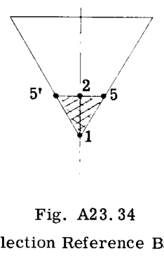

図 A23.34

ここでは、点 1 と 5 における変位がゼロであり、基準三角形を固定している。対称性により、翼のもう一方の半分における 5 に対応する点（例えば 5’）もゼロ変位となるためである。3番目の条件は点 2 に適用される。点 2 は、対称な翼荷重に対してはゼロのロール回転（ $u_{12} = 0$ ）を持ち、非対称な荷重に対してはゼロの横方向変位（ $u_2 = 0$ ）を持つと仮定される。*

したがって、以下の式（行と列）が翼剛性マトリクスから省略される。

$$\left. \begin{array}{l} F_1, u_1 \\ F_5, u_5 \\ F_{12}, u_{12}
\end{array} \right\} \text{対称荷重の場合}$$

$$\left. \begin{array}{l} F_1, u_1 \\ F_5, u_5 \\ F_2, u_2 \end{array}
\right\} \text{非対称荷重の場合}$$

両方のケースにおいて、 $16 \times 16$ マトリクスから追加の方程式が消去され、さらに縮小されることがわかる。一般に、対称ケースと非対称ケースのマトリクスが同じサイズである必要はない。これらのケースにおいて、適用される荷重のモデリングが同じではないためである（例えば、非対称荷重では、力 $F_1$ 、 $F_2$ 、 $F_3$ 、または $F_4$ は適用されない）。

以下に記述されているのは、対称ケース（ $u_1 = u_5 = u_{11} = u_{12} = u_{13} = u_{14} = 0$ ）に対する $13 \times 13$ の翼剛性マトリクスである。先に説明したように、そこにおける各エントリは、その点において交わるすべての要素に対する、対応するすべての剛性の総和である。典型的な複数エントリは、ジョイント 6（行 $F_6$ 、列 $u_6$ ）で発生する。これらは以下で構成される。

$$\begin{array}{ll} 0.007065 & \text{スパー 3-6-8 から} \\ 0.001730
& \text{リブ 5-6-7 から} \\ 0.000310 & \text{ボックス 6-7-8-9
から} \\ 0.000898 & \text{ボックス 2-3-5-6 から} \\ 0.000482 &
\text{ボックス 3-4-6-7 から} \\ \hline 0.010485 & \text{合計}
\end{array}$$

$$K_{\substack{\text{Wing} \\ \text{Symm.}}} = \begin{array}{c} \\ F_2 \\
F_3 \\ F_4 \\ F_6 \\ F_7 \\ F_8 \\ F_9 \\ F_{10} \\ F_{15} \\ F_{16} \\
F_{21} \\ F_{25} \\ F_{28} \end{array} \left[
\begin{array}{ccccccccccccc} u_2 & u_3 & u_4 & u_6 & u_7
& u_8 & u_9 & u_{10} & u_{15} & u_{18} & u_{21}
& u_{25} & u_{28} \\ \hline 0.4299 & -.2670 & .07314
& .000898 & & & & & .07616 & & -5.393
& & \\ -.2670 & .2753 & -.1027 & -.005429 &
.000482 & .001332 & & & & -.01700 & 1.449 &
& \\ .07314 & -.1027 & .04629 & .000482 & -.0009328
& & .0001586 & -.00002122 & & & -.2450 &
& \\ .000898 & -.005429 & .000482 & .010485 &
-.001380 & -.003326 & .000310 & & & .05558 &
& -.02658 & \\ & .000482 & -.0009328 & -.001380
& .001776 & .000310 & -.0006789 & .00008089 & &
& & .004706 & \\ & .001332 & & -.003326 &
.000310 & .002564 & -.0004515 & -.0000499 & -.009686
& -.04470 & & -.009686 & .000664 \\ & & .0001586
& .000310 & -.0006789 & -.0004515 & .0007662 &
-.0001045 & & & & & -.006796 \\ & &
-.00002122 & & -.00008089 & -.000499 & -.0001045 &
.0000947 & & -.002394 & & & -.002394 \\ .07616 &
& & & & -.009686 & & & 2.9213 & .1425
& .2004 & .7043 & .1425 \\ & -.0170 & & .05558
& & -.04470 & & -.002394 & .1425 & 1.6937 &
& .1425 & .3817 \\ -5.393 & 1.449 & -.2450 & &
& & & & .2004 & & 155.44 & .2004 & \\
& & & -.02658 & .004706 & -.009686 & & &
.7043 & .1425 & .2004 & 1.5285 & .1425 \\ & &
& & & .000664 & -.006796 & -.002394 & .1425
& .3817 & & .1425 & .7078 \end{array} \right]$$

## 縮小翼剛性マトリクス

上記のように導出された翼剛性マトリクスは、対称荷重下での翼の挙動を正しく表すために必要なすべての幾何学的拘束を含んでいる。しかし、使用される外力モデルのために純粋に存在する特定のゼロ荷重拘束を適用することによって、さらに縮小することができる。具体的には、荷重モデリングにおいて、偶力 $F_{15}$ 、 $F_{18}$ 、 $F_{21}$ 、 $F_{25}$ 、および $F_{28}$ をゼロに等しいと設定する。したがって、式35を使用して縮小マトリクスを導出することができる。この縮小マトリクスは、翼の影響係数の導出（翼剛性マトリクスのインバージョンによる）および翼の内部応力（すなわち、特定の要素荷重）の導出というさらなる計算タスクが引き受けられる場合に、より単純な取り扱いが可能になるという利点を提供する。

## A23.12 精度、収束、および誤差範囲

私たちは2種類の精度に対処しなければならない。第一に、有限要素モデルに関連する精度、第二に、モデルが選択された後の数値解に関連する精度である。計算機によって多くの桁数まで与えられた結果であっても、モデルの概念的な欠陥や解法の計算上の欠陥のために、役に立たない可能性があることを指摘しておく価値がある。

2つのプロセスのうち、有限要素モデルの選択は、経験と判断により依存する。一部の種類の要素では、より多くの（より小さい）要素を持つモデルのシーケンスをとることによって、厳密解（弾性論または連続体）への収束が保証される。例題5および6はこの状況を示している。同様の境界条件を持つ制限されたより単純な問題を考慮することによって、望ましい結果を境界付けることは価値があるかもしれない。高い応力およびひずみ勾配の領域では、応力と変位の有用な値を得ることを確実にするために、結果のモデリングと解釈において細心の注意を払わなければならない。

数値解に関して、変位法から導出される剛性マトリクスは正定値対称マトリクスであり、これに対して非自明で一意な解が先験的に保証される。本当の難しさは、これらの解を決定するための計算効率の高いアルゴリズムを見つけることにある。

本章の例題では、剛性マトリクスのインバージョンによる直接解（例題1）やガウス消去法による解（例題3）、ガウス・サイデルアルゴリズムによる反復解（例題2）など、いくつかの方法が示されている。大雑把な経験則として、直接解は小さく密なマトリクスに最適であり、両方のタイプの解が大きく疎なマトリクスに使用される。好ましい解決方法、および大規模な問題と小規模な問題の境界は、専門家によって異なり、実際、特定の施設における選択は、いずれかのタイプの信頼性が高くデバッグ済みの手順によって無効にされる場合がある。問題の管理も最適化されるべきである。例えば、可能であれば、記憶容量の要件を最小限に抑えるために、帯状の剛性マトリクスを生成するように節点を番号付けする必要がある。

数値計算を容易にするために、特定の実際的な措置を講じることができる。1つ以上の非常に剛性の高い要素がある場合、問題の条件を良くするために、関連する座標を消去することができる（例題2のように）。

計算誤差は、丸め誤差と打切り誤差と呼ばれる2つの原因から発生する。丸め誤差は、計算において有限の桁数が保持されるために発生する。有効数字の損失を避けるために、倍精度演算が必要となることが多い。一部のアルゴリズムでは、引き算における有効数字の損失を避け、より良い精度を達成するために、行と列のペアを入れ替えることによって操作の順序が変更される。打切り誤差は通常、反復法に関連しており、その精度は無限回のステップを完了することによってのみ保証される。有限回の反復の後に計算を終了することにより、打切り誤差が発生する。マトリクス係数が経験的に得られる場合、さらなる誤差が発生する可能性がある。誤差に境界を設けることは、計算手順の困難ではあるが重要な部分である。詳細については、数値解析に関する文献（5, 6）を参照されたい。

## A23.13 コンピュータによる問題の管理

電子デジタルコンピュータ上での構造問題の解決の管理に関する議論は、容易に別の本を占める可能性がある。ここでは、読者が検討し、コンピュータコンサルタントと話し合うべき質問へのガイドとして考慮できるトピックのチェックリストを提示するにとどめる。コンピュータ解析を実行することの望ましさと実現可能性がすでに決定され、分析的アプローチが選択されていると仮定する。

この時点での重要な要因は、特定の精度に対する計算のコストである。採用される方法、したがってコストは、地域のコンピュータ施設における料金体系と密接に関連している。多くの場合、計算の中心ではないコストが支配的になる。典型的な課金レートには、中央処理装置時間、入出力リクエスト数、および必要な記憶領域サイズが含まれる。カードや印刷出力のコスト、テープやディスクの保管料、グラフィックプロッタの使用料などの他の要因は、比例配分されるか、直接課金される場合がある。特定のコンピュータでは、通常、料金体系の要素の1つがプログラミング戦略を支配する。コンピュータの進化の初期段階では、処理時間と記憶容量が制限要因であった。これらの分野における改善に伴い、現在のコンピュータ技術は入出力の制限に縛られることが多い。コストの考慮に加えて、データ入力で重大なミスを犯す可能性から、特別なデータ生成ルーチンやチェックプログラムの使用がもたらされた。グラフィカルな出力は、節点位置の誤りの検出や要素定義のチェックにおいて特に有用である。入出力コストのため、プログラムの大部分をコア記憶装置に保持することが望ましい。情報を保存して呼び出すコストは、データを再生成するコストを10倍、20倍、あるいはそれ以上上回る場合がある。中央処理装置との間でデータを移動する場合、使用されるフォーマットがコストに決定的な影響を与える可能性がある。利用可能な最も単純なフォーマット定義を使用して、一度に多くのレコード行を転送することが有利な場合が多い。

すべてのプログラムには、信頼できる本番実行を実行する前に発見して修正しなければならないエラーやバグが含まれている。タイムシェアリングシステムで動作するオンライン端末の使用は、実行間の待ち時間の大部分を排除するため、デバッグの効率的な方法である。これは、スペルや構文の誤りを発見するための初期の実行中に特に役立つ。多くの場合、マシンの障害によって完了前に実行が終了する。すべての実行から何かを学ぶために、中間結果を出力することが望ましい。プログラムの各部分の実行時間は容易にチェックでき、再プログラミングが最も生産的となる計算部分を特定することができる。

プログラムが本番用に準備できたら、FORTRAN や PL/I ではなく、機械語でコンパイルしてテープやディスクに保存する必要がある。これにより、実行ごとの時間を大幅に節約できる。可能な場合は、確立され広く使用されているプログラムを使用する必要がある。新しいプログラムの場合、デバッグが結果を得るために必要な作業のかなりの割合を占めるためである。しかし、文書化が不十分なプログラムには注意しなければならない。学習サイクルのコストが、新しいプログラムの作成とデバッグのコストを容易に超える可能性があるためである。

## 参考文献

1. Rubinstein, M. F., *Structural Systems - Statics, Dynamics and Stability*, Prentice-Hall, Englewood Cliffs, N. J., 1970.
2. Rubinstein, M. F., *Matrix Computer Analysis of Structures*, Prentice-Hall, Englewood Cliffs, N. J., 1966.
3. Przemieniecki, J. S., *Theory of Matrix Structural Analysis*, McGraw-Hill, New York, 1968.
4. Zienkiewicz, *The Finite Element Method in Structural and Continuum Mechanics*, McGraw-Hill, Ltd., London, 1967.
5. Crandall, S. H., *Engineering Analysis*, McGraw-Hill, New York, 1956.
6. Ralston, A., *A First Course in Numerical Analysis*, McGraw-Hill, New York, 1965.
7. Sokolnikoff, I. S., *Mathematical Theory of Elasticity*, McGraw-Hill, New York, 1956.
8. Levy, S., “Structural Analysis and Influence Coefficients for Delta Wings”, *Journal of the Aeronautical Sciences*, 20, 1953.
9. Schuerch, H., “Delta Wing Design Analysis”, *Society of Automotive Engineers National Aeronautic Meeting Preprint* No. 141, September, 1953.
10. Turner, M. J., Clough, R. W., Martin, H. C., and Topp, L. J., “Stiffness and Deflection Analysis of Complex Structures”, *Journal of the Aeronautical Sciences*, 23, September, 1956.
11. Kroll, W., “Effect of Rib Flexibility on the Vibration Modes of a Delta Wing Aircraft”, *Institute of Aeronautical Sciences, Preprint* No. 585, 1956.
12. Wooley, Ruth, “Check of Method for Computing Influence Coefficients of Delta and Other Wings”, *National Bureau of Standards Report* 3655, 1954. (Available as ASTIA No. AD46866).
13. Williams, D., “Recent Developments in the Structural Approach to Aeroelastic Problems”, *Journal of the Royal Aeronautical Society*, 58, 1954 (see also, *Aircraft Engineering*, 25, 1954).
- この $GJ$ の計算については後述する。
- ここでの含意は、梁のねじり剛性がそのような相互作用において考慮されないということである。一般に曲げ剛性はほとんどの梁要素においてねじり剛性よりもはるかに大きいため、この仮定はおそらく十分に満足のいくものである。場合によっては、梁がかなりのねじり剛性を持つことがあり、その場合はそれを考慮する必要がある。前縁スパーは、モデル化において翼の “D” ノーズセクションを置き換える場合、そのような梁になる可能性がある。
- 非対称荷重パターンは、翼の2つの半分における対応する点において、翼が等しく、しかし逆の方向に荷重を受けるパターンである。任意の一般的な荷重は、1つの対称荷重と1つの非対称荷重の和に分解することができる。